# Yuen’s t-Test: Type I Error with DescTools vs. WRS2

Carolin Kirsch

```r
knitr::opts_chunk$set(message = FALSE, warning = FALSE)

library(dplyr)
library(tidyverse)
library(tidyr)
library(ggplot2)
library(flextable)
library(apa7)
library(ftExtra)
library(DescTools)
library(WRS2)
library(furrr)

set_flextable_defaults(theme_fun = theme_apa,
                        font.family = "Times New Roman")
```

```r
source("functions.R")
```

```r
n_iterations <-  30000L
alpha <- 0.05
```

Estimate the empirical Type I error rate of Yuen’s t-test across four trimming parameters, c ∈ {0.1, 0.15, 0.2, 0.25}, and a wide range of sample sizes (up to roughly n = 500 per group), comparing two implementations: `DescTools::YuenTTest()` and `WRS2::yuen()`. The two packages compute the winsorized variance differently. `DescTools` interpolates between order statistics via `quantile(type = 7)`, while `WRS2` uses a plain floor-based index cutoff (`WRS2:::winvar`). They only agree exactly when the interpolation index happens to be a whole number. Sample sizes are chosen in triplets (n, n+1, n+2 around anchors that are multiples of 20) so that all three possible cases — exact agreement, and interpolation in each direction — occur, simultaneously, for all four trim parameters.

# functions

## data analysis: Yuen’s t-test, two implementations

```r
analyse_data_yuen_methods <- function(n, trim) {
  data <- generate_data_ttest(n_control = n)
  tibble(
    method = c("DescTools", "WRS2"),
    p_value = c(
      YuenTTest(score ~ condition, data, alternative = "two.sided", trim = trim)$p.value,
      yuen(score ~ condition, data, tr = trim)$p.value
    )
  )
}
```

## classify a (n, trim) cell by how DescTools’ and WRS2’s winsorization cutoffs relate

```r
classify_cell <- function(n, trim, tol = 1e-8) {
  x    <- seq_len(n)
  q_lo <- as.numeric(quantile(x, probs = trim, type = 7))   # DescTools cutoff
  o_lo <- x[floor(trim * n) + 1]                             # WRS2 cutoff
  case_when(
    abs(q_lo - o_lo) < tol ~ "A_exact",
    q_lo > o_lo             ~ "B_interp_above",
    TRUE                    ~ "B_interp_below"
  )
}
```

# simulation

## design: sample-size triplets shared across trim parameters

```r
trims <- c(0.10, 0.15, 0.20, 0.25)
q_shared <- 20L
n_max <- 500L

anchors <- unique(round(exp(seq(log(20), log(n_max), length.out = 16))))
n_base <- pmax(q_shared, round(anchors / q_shared) * q_shared)
n_base <- if_else(n_base > n_max - 2L, floor((n_max - 2L) / q_shared) * q_shared, n_base)
n_base <- unique(n_base)

n_design <- expand_grid(n_base = n_base, offset = 0:2) |>
  mutate(n = n_base + offset)

n_design
```

```
## # A tibble: 36 × 3
##    n_base offset     n
##     <dbl>  <int> <dbl>
##  1     20      0    20
##  2     20      1    21
##  3     20      2    22
##  4     40      0    40
##  5     40      1    41
##  6     40      2    42
##  7     60      0    60
##  8     60      1    61
##  9     60      2    62
## 10     80      0    80
## # ℹ 26 more rows
```

## design verification

Before running the full simulation: confirm that each offset (0/1/2) maps to exactly one case, consistently across all four trims. This must be a perfect diagonal.

```r
design_check <- expand_grid(n_design, trim = trims) |>
  mutate(case = map2_chr(n, trim, classify_cell))

design_check |> count(offset, case)
```

```
## # A tibble: 3 × 3
##   offset case               n
##    <int> <chr>          <int>
## 1      0 B_interp_below    48
## 2      1 A_exact           48
## 3      2 B_interp_above    48
```

## simulation grid

```r
par_grid_yuen_trim <- expand_grid(
  n_design,
  trim = trims,
  iteration = 1:n_iterations
)
```

```r
sim_yuen_trim_file <- paste0("results_UBELIX/sim_yuen_trim_", n_iterations, "iterations.rds")
yuen_sessionInfo_file <- paste0("results_UBELIX/yuen_sessionInfo_", n_iterations, "iterations.txt")

# session info is recorded only when the simulation actually runs (not on re-renders from cache)
if (!file.exists(sim_yuen_trim_file)) {
  set.seed(9182)
  plan(multisession, workers = future::availableCores())

  sim_yuen_trim <- par_grid_yuen_trim |>
    mutate(
      analysis_result = future_map2(
        n, trim, analyse_data_yuen_methods,
        .options = furrr_options(seed = TRUE),
        .progress = TRUE
      ),
      case            = map2_chr(n, trim, classify_cell)
    ) |>
    unnest(analysis_result)

  saveRDS(sim_yuen_trim, sim_yuen_trim_file)
  writeLines(capture.output(sessionInfo()), yuen_sessionInfo_file)
} else {
  sim_yuen_trim <- readRDS(sim_yuen_trim_file)
}
```

# results

## summary: empirical Type I error by trim, n, case, and method

```r
sim_summary_yuen_trim_file <- paste0("results_UBELIX/sim_summary_yuen_trim_", n_iterations, "iterations.rds")

if (!file.exists(sim_summary_yuen_trim_file)) {
  sim_summary_yuen_trim <- sim_yuen_trim |>
    group_by(trim, n, offset, case, method) |>
    summarize(
      empirical_detection_rate = mean(p_value < alpha),
      empirical_detection_rate_mcse = sqrt(empirical_detection_rate * (1 - empirical_detection_rate) / n()),
      .groups = "drop"
    ) |>
    mutate(
      empirical_detection_rate_95CI_low = empirical_detection_rate - empirical_detection_rate_mcse * 1.96,
      empirical_detection_rate_95CI_upp = empirical_detection_rate + empirical_detection_rate_mcse * 1.96,
    )

  saveRDS(sim_summary_yuen_trim, sim_summary_yuen_trim_file)
} else {
  sim_summary_yuen_trim <- readRDS(sim_summary_yuen_trim_file)
}

sim_summary_yuen_trim
```

```
## # A tibble: 288 × 9
##     trim     n offset case  method empirical_detection_…¹ empirical_detection_…²
##    <dbl> <dbl>  <int> <chr> <chr>                   <dbl>                  <dbl>
##  1   0.1    20      0 B_in… DescT…                 0.0473                0.00123
##  2   0.1    20      0 B_in… WRS2                   0.0503                0.00126
##  3   0.1    21      1 A_ex… DescT…                 0.049                 0.00125
##  4   0.1    21      1 A_ex… WRS2                   0.049                 0.00125
##  5   0.1    22      2 B_in… DescT…                 0.0518                0.00128
##  6   0.1    22      2 B_in… WRS2                   0.0493                0.00125
##  7   0.1    40      0 B_in… DescT…                 0.0464                0.00121
##  8   0.1    40      0 B_in… WRS2                   0.0477                0.00123
##  9   0.1    41      1 A_ex… DescT…                 0.0480                0.00123
## 10   0.1    41      1 A_ex… WRS2                   0.0480                0.00123
## # ℹ 278 more rows
## # ℹ abbreviated names: ¹empirical_detection_rate,
## #   ²empirical_detection_rate_mcse
## # ℹ 2 more variables: empirical_detection_rate_95CI_low <dbl>,
## #   empirical_detection_rate_95CI_upp <dbl>
```

## plot

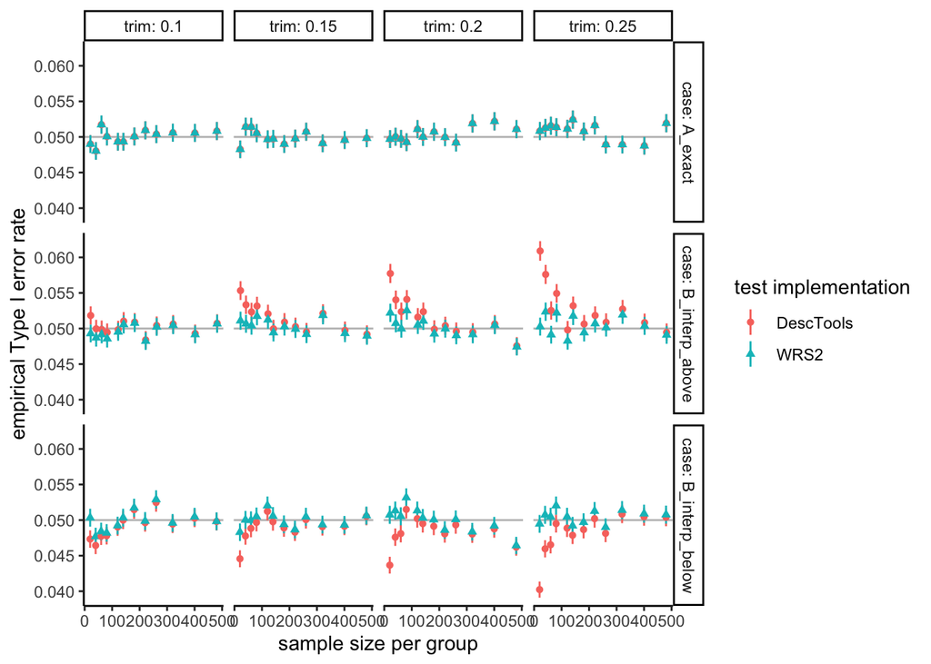

```r
ggplot(sim_summary_yuen_trim,
       aes(x = n,
           y = empirical_detection_rate,
           color = method,
           shape = method)) +
  geom_hline(yintercept = alpha, colour = "grey") +
  geom_linerange(aes(ymin = empirical_detection_rate - empirical_detection_rate_mcse,
                      ymax = empirical_detection_rate + empirical_detection_rate_mcse)) +
  geom_point() +
  facet_grid(case ~ trim, labeller = label_both) +
  labs(
    x = "sample size per group",
    y = "empirical Type I error rate",
    color = "test implementation",
    shape = "test implementation") +
  theme(text = element_text(size = 14)) +
  theme_classic()
```

*Note.* Lineranges show ±1 Monte Carlo standard error (MCSE) of the empirical Type I error rate; maximum MCSE across all conditions = .001. The grey line indicates the nominal $\alpha = .05$.

## session information of the simulation run

```r
cat(readLines(yuen_sessionInfo_file), sep = "\n")
```

[output not shown]